# Self-Driving Car Engineer Nanodegree

## Project: Build a Traffic Sign Recognition Classifier

## Step 0: Load The Data

```python
# Load pickled data
import pickle

# TODO: Fill this in based on where you saved the training and testing data

training_file = './load_data/train.p'
validation_file= './load_data/valid.p'
testing_file = './load_data/test.p'

with open(training_file, mode='rb') as f:
    train = pickle.load(f)
with open(validation_file, mode='rb') as f:
    valid = pickle.load(f)
with open(testing_file, mode='rb') as f:
    test = pickle.load(f)

X_train, y_train = train['features'], train['labels']
X_valid, y_valid = valid['features'], valid['labels']
X_test, y_test = test['features'], test['labels']
```

## Step 1: Dataset Summary & Exploration

The pickled data is a dictionary with 4 key/value pairs:

- `'features'` is a 4D array containing raw pixel data of the traffic sign images, (num examples, width, height, channels).
- `'labels'` is a 1D array containing the label/class id of the traffic sign. The file `signnames.csv` contains id -> name mappings for each id.
- `'sizes'` is a list containing tuples, (width, height) representing the original width and height the image.
- `'coords'` is a list containing tuples, (x1, y1, x2, y2) representing coordinates of a bounding box around the sign in the image. **THESE COORDINATES ASSUME THE ORIGINAL IMAGE. THE PICKLED DATA CONTAINS RESIZED VERSIONS (32 by 32) OF THESE IMAGES**

Complete the basic data summary below. Use python, numpy and/or pandas methods to calculate the data summary rather than hard coding the results. For example, the [pandas shape method](http://pandas.pydata.org/pandas-docs/stable/generated/pandas.DataFrame.shape.html) might be useful for calculating some of the summary results.

### Provide a Basic Summary of the Data Set Using Python, Numpy and/or Pandas

```python
### Replace each question mark with the appropriate value.
### Use python, pandas or numpy methods rather than hard coding the results

# TODO: Number of training examples
n_train = len(X_train)

# TODO: Number of testing examples.
n_test = len(X_test)

# TODO: What's the shape of an traffic sign image?
image_shape = X_train[0].shape

# TODO: How many unique classes/labels there are in the dataset.
n_classes = len(set(y_test))

print("Number of training examples =", n_train)
print("Number of testing examples =", n_test)
print("Image data shape =", image_shape)
print("Number of classes =", n_classes)
```

```
Number of training examples = 34799
Number of testing examples = 12630
Image data shape = (32, 32, 3)
Number of classes = 43
```

### Include an exploratory visualization of the dataset

Visualize the German Traffic Signs Dataset using the pickled file(s). This is open ended, suggestions include: plotting traffic sign images, plotting the count of each sign, etc

```
It is shown 43 class images of train dataset
```

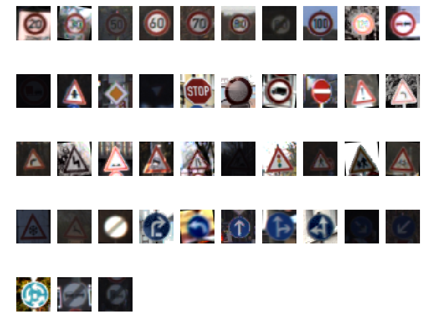

```python
### Data exploration visualization code goes here.
### Feel free to use as many code cells as needed.
import numpy as np
import matplotlib.pyplot as plt
# Visualizations will be shown in the notebook.
%matplotlib inline

print('It is shown 43 class images of train dataset')
plt.figure(figsize=(12,10))
for i in range(43):
    features = X_train[np.where(y_train == i)]

    plt.subplot(5,10,i+1)
    image = features[0]
    plt.axis('off')
    plt.imshow(image)
```

## Step 2: Design and Test a Model Architecture

Design and implement a deep learning model that learns to recognize traffic signs. Train and test your model on the [German Traffic Sign Dataset](http://benchmark.ini.rub.de/?section=gtsrb&subsection=dataset).

The LeNet-5 implementation shown in the classroom at the end of the CNN lesson is a solid starting point. You'll have to change the number of classes and possibly the preprocessing, but aside from that it's plug and play!

With the LeNet-5 solution from the lecture, you should expect a validation set accuracy of about 0.89. To meet specifications, the validation set accuracy will need to be at least 0.93. It is possible to get an even higher accuracy, but 0.93 is the minimum for a successful project submission.

There are various aspects to consider when thinking about this problem:

- Neural network architecture (is the network over or underfitting?)
- Play around preprocessing techniques (normalization, rgb to grayscale, etc)
- Number of examples per label (some have more than others).
- Generate fake data.

Here is an example of a [published baseline model on this problem](http://yann.lecun.com/exdb/publis/pdf/sermanet-ijcnn-11.pdf). It's not required to be familiar with the approach used in the paper but, it's good practice to try to read papers like these.

### Pre-process the Data Set (normalization, grayscale, etc.)

Use the code cell (or multiple code cells, if necessary) to implement the first step of your project.

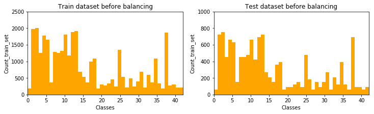

```python
# Each classes' train dataset size
fig = plt.figure(figsize=(12,3))
plt.subplot(1,2,1)
plt.axis([0, 42, 0, 2500])
plt.hist(y_train, n_classes, color='orange')
plt.title('Train dataset before balancing')
plt.xlabel('Classes')
plt.ylabel('Count_train_set')

# Each classes' test dataset size
plt.subplot(1,2,2)
plt.axis([0, 42, 0, 1000])
plt.hist(y_test, n_classes, color='orange')
plt.title('Test dataset before balancing')
plt.xlabel('Classes')
plt.ylabel('Count_train_set')

plt.show()
```

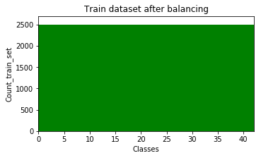

```python
### Preprocess the data here. Preprocessing steps could include normalization, converting to grayscale, etc.
### Feel free to use as many code cells as needed.
import cv2
import numpy as np

def Preprocessing_steps(image, rot_angle):

    """Applies a Histogram Equalization"""
    switch = np.random.randint(0, 2)

    if switch == 1:
        img_yuv = cv2.cvtColor(image, cv2.COLOR_BGR2YUV)

        # equalize the histogram of the Y channel
        img_yuv[:,:,0] = cv2.equalizeHist(img_yuv[:,:,0])

        # convert the YUV image back to RGB format
        image = cv2.cvtColor(img_yuv, cv2.COLOR_YUV2BGR)

    """Applies a random rotation"""
    switch2 = np.random.randint(0, 2)

    if switch2 == 1:
        rows,cols = image.shape[:2]
        rand_ang = np.random.uniform(-rot_angle, rot_angle)
        rot_mat = cv2.getRotationMatrix2D((cols/2, rows/2), rand_ang, 1.0)

        image = cv2.warpAffine(image , rot_mat, (cols,rows))

    result = image

    return result

class_bincount = np.bincount(y_train)

for i in range(n_classes):
    new_features, new_labels = [], []
    features = X_train[np.where(y_train == i)]

    # the number of adding images
    add_count = 2500 - class_bincount[i]
    for j in range(add_count):
        rand_img = np.random.randint(class_bincount[i])
        new_features.append(Preprocessing_steps(features[rand_img], 10))
        new_labels.append(i)

    X_train = np.append(X_train, new_features, axis=0)
    y_train = np.append(y_train, new_labels, axis=0)

del new_features, new_labels

# Each classes' train dataset size after balancing
fig = plt.figure(figsize=(12,3))
plt.subplot(1,2,1)
plt.axis([0, 42, 0, 2700])
plt.hist(y_train, n_classes, color='green')
plt.title('Train dataset after balancing')
plt.xlabel('Classes')
plt.ylabel('Count_train_set')

plt.show()
```

```
I make balanced image datasets of 2500 elements in the each classes.

It is shown 50 elements of balanced train dataset of 0 classID.

Add image sets are ...
- Randomly, equalize the histogram of the Y channel
- Randomly, image rotate
```

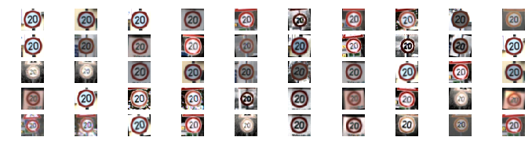

```python
# show 50 of balanced train dataset
print('I make balanced image datasets of 2500 elements in the each classes.\n')
print('It is shown 50 elements of balanced train dataset of 0 classID.\n')
print('Add image sets are ...')
print('- Randomly, equalize the histogram of the Y channel')
print('- Randomly, image rotate')

features = X_train[np.where(y_train == 0)]
plt.figure(figsize=(12,3))
for i in range(50):
    plt.subplot(5,10,i+1)
    random = np.random.randint(0, n_train)
    image = features[np.random.randint(0, 2400)]
    plt.axis('off')
    plt.imshow(image)
```

```python
from sklearn.utils import shuffle
from sklearn.model_selection import train_test_split

# shuffle the train dataset
X_train, y_train = shuffle(X_train, y_train)

# split data into training and validation set (80 : 20)
X_train_set, X_valid_set, y_train_set, y_valid_set = train_test_split(X_train,y_train,test_size=0.2,
                                                                      random_state = np.random.randint(0, len(X_train)))
```

# Answer:

# 1. Dataset balancing

# 2. Normalization

- all images of dataset make resize (32x32)
- When it add balanced image datasets, ..
- ... Randomly, equalize the histogram of the Y channel
- ... Randomly, image rotate

# 3. Shuffle data

- The data is sorted by class.
- I didn't use translation when make an additional test image.
- There were no effect of normalization(0, 255 -> 0, 1) because already all image's value range is same.

### Model Architecture

```python
import tensorflow as tf
from tensorflow.contrib.layers import flatten

weights = {
    'w_conv1': tf.get_variable('w_conv1', [3, 3, 3, 16],initializer=tf.contrib.layers.xavier_initializer()),
    'w_conv2': tf.get_variable('w_conv2', [3, 3, 16, 16],initializer=tf.contrib.layers.xavier_initializer()),
    'w_conv3': tf.get_variable('w_conv3', [3, 3, 16, 64],initializer=tf.contrib.layers.xavier_initializer()),
    'w_conv4': tf.get_variable('w_conv4', [3, 3, 64, 64],initializer=tf.contrib.layers.xavier_initializer()),
    'w_conv5': tf.get_variable('w_conv5', [3, 3, 64, 128],initializer=tf.contrib.layers.xavier_initializer()),
    'w_conv6': tf.get_variable('w_conv6', [3, 3, 128, 128],initializer=tf.contrib.layers.xavier_initializer()),
    'w_conv7': tf.get_variable('w_conv7', [3, 3, 128, 128],initializer=tf.contrib.layers.xavier_initializer()),
    'w_conv8': tf.get_variable('w_conv8', [3, 3, 128, 128],initializer=tf.contrib.layers.xavier_initializer()),
    'w_fc1': tf.get_variable('w_fc1', [1152, 512],initializer=tf.contrib.layers.xavier_initializer()),
    'w_fc2': tf.get_variable('w_fc2', [512, 256],initializer=tf.contrib.layers.xavier_initializer()),
    'w_fc3': tf.get_variable('w_fc3', [256, 43],initializer=tf.contrib.layers.xavier_initializer())
}

biases = {
    'b_fc3': tf.Variable(tf.zeros([43]),name='b_fc3')
}
```

```python
def Conv_layer(in_layer, weight, pad='SAME', pooling=False, is_training=True, reuse=False):

    """ weight init : he_init , bias_init : zero """
    out_layer = tf.nn.conv2d(in_layer, weight, strides=[1, 1, 1, 1], padding=pad) #+ bias

    """ using Batch Normalization """
    out_layer = tf.contrib.layers.batch_norm(out_layer, is_training=is_training,
                    center=True, scale=True, activation_fn=tf.nn.relu, trainable=True, decay=0.9, updates_collections=None, reuse = reuse)
    """ activation func : Relu """
    out_layer = tf.nn.relu(out_layer)

    if pooling==True:
        """ Pooling method : Max Pooling """
        out_layer = tf.nn.max_pool(out_layer, ksize=[1, 2, 2, 1], strides=[1, 2, 2, 1], padding='SAME')

    return out_layer

def FC_layer(in_layer, weight, is_training=True, reuse=False):

    """ weight init : he_init , bias_init : zero """
    out_layer   = tf.matmul(in_layer, weight) #+  bias

    """ using Batch Normalization """
    out_layer = tf.contrib.layers.batch_norm(out_layer, is_training=is_training,
                    center=True, scale=True, activation_fn=tf.nn.relu, trainable=True, decay=0.9, updates_collections=None, reuse = reuse)
    """ activation func : Relu """
    out_layer    = tf.nn.relu(out_layer)

    return out_layer
```

```python
### Visualize your network's feature maps here.
### Feel free to use as many code cells as needed.

# image_input: the test image being fed into the network to produce the feature maps
# tf_activation: should be a tf variable name used during your training procedure that represents the calculated state of a specific weight layer
# activation_min/max: can be used to view the activation contrast in more detail, by default matplot sets min and max to the actual min and max values of the output
# plt_num: used to plot out multiple different weight feature map sets on the same block, just extend the plt number for each new feature map entry

def outputFeatureMap(image_input, tf_activation, activation_min=-1, activation_max=-1 ,plt_num=1):
    # Here make sure to preprocess your image_input in a way your network expects
    # with size, normalization, ect if needed
    # image_input =
    # Note: x should be the same name as your network's tensorflow data placeholder variable
    # If you get an error tf_activation is not defined it maybe having trouble accessing the variable from inside a function
    activation = tf_activation.eval(session=sess,feed_dict={x : image_input})
    featuremaps = activation.shape[3]
    plt.figure(plt_num, figsize=(15,15))
    for featuremap in range(featuremaps):
        plt.subplot(6,8, featuremap+1) # sets the number of feature maps to show on each row and column
        plt.title('FeatureMap ' + str(featuremap)) # displays the feature map number
        if activation_min != -1 & activation_max != -1:
            plt.imshow(activation[0,:,:, featuremap], interpolation="nearest", vmin =activation_min, vmax=activation_max, cmap="gray")
        elif activation_max != -1:
            plt.imshow(activation[0,:,:, featuremap], interpolation="nearest", vmax=activation_max, cmap="gray")
        elif activation_min !=-1:
            plt.imshow(activation[0,:,:, featuremap], interpolation="nearest", vmin=activation_min, cmap="gray")
        else:
            plt.imshow(activation[0,:,:, featuremap], interpolation="nearest", cmap="gray")
```

```python
x = tf.placeholder(tf.float32, (None, 32, 32, 3))
y = tf.placeholder(tf.int32, (None))
# Boolean for MODE of train or test
is_training = tf.placeholder(tf.bool, name='MODE')
reuse = tf.placeholder(tf.bool, name='MODE')
# one_hot_y = tf.one_hot(y, 43)
# To solve a CUDA Error. https://github.com/tensorflow/tensorflow/issues/6509
num_labels = 43
sparse_labels = tf.reshape(y, [-1, 1])
derived_size = tf.shape(sparse_labels)[0]
indices = tf.reshape(tf.range(0, derived_size, 1), [-1, 1])
concated = tf.concat(1, [indices, sparse_labels])
outshape = tf.concat(0, [tf.reshape(derived_size, [1]), tf.reshape(num_labels, [1])])
one_hot_y = tf.sparse_to_dense(concated, outshape, 1.0, 0.0)

rate = 0.001
#beta = 0.00001

# My Model Start...
# Input = 32x32x3 -> Conv1 = 32x32x16
conv1 = Conv_layer(x, weights['w_conv1'], pad='SAME', pooling=False, is_training=True, reuse=False)

# Conv1 = 32x32x16 -> Conv2 = 32x32x16 -> conv2_Pooling = 16x16x16
conv2 = Conv_layer(conv1, weights['w_conv2'], pad='SAME', pooling=True, is_training=True, reuse=False)

# Conv2_Pooling = 16x16x16 -> Conv3 = 16x16x64
conv3 = Conv_layer(conv2, weights['w_conv3'], pad='SAME', pooling=False, is_training=True, reuse=False)

# Conv3 = 16x16x64 -> Conv4 = 16x16x64 -> conv4_Pooling = 8x8x64
conv4 = Conv_layer(conv3, weights['w_conv4'], pad='SAME', pooling=True, is_training=True, reuse=False)

# Conv4_Pooling = 8x8x64 -> Conv5 = 8x8x128
conv5 = Conv_layer(conv4, weights['w_conv5'], pad='SAME', pooling=False, is_training=True, reuse=False)

# Conv5 = 8x8x128 -> Conv6 = 6x6x128 -> conv6_Pooling = 3x3x128
conv6 = Conv_layer(conv5, weights['w_conv6'], pad='VALID', pooling=True, is_training=True, reuse=False)

# Conv6_Pooling = 3x3x128 -> Conv7 = 3x3x128
conv7 = Conv_layer(conv6, weights['w_conv7'], pad='SAME', pooling=False, is_training=True, reuse=False)

# Conv7 = 3x3x128 -> Conv8 = 3x3x128
conv8 = Conv_layer(conv7, weights['w_conv8'], pad='SAME', pooling=False, is_training=True, reuse=False)

# Flatten. 3x3x128 -> 1152
fc0 = flatten(conv8)

# FC0 = 1152 -> FC1 = 512
fc1 = FC_layer(fc0, weights['w_fc1'],is_training=True, reuse=False)

# FC1 = 512 -> FC2 = 256
fc2 = FC_layer(fc1, weights['w_fc2'], is_training=True, reuse=False)

# FC2 = 256 -> FC3 = 43
logits = tf.matmul(fc2, weights['w_fc3']) + biases['b_fc3']

print(conv1)
print(conv2)
print(conv3)
print(conv4)
print(conv5)
print(conv6)
print(conv7)
print(conv8)
print(fc0)
print(fc1)
print(fc2)
print(logits)

L2_loss = (tf.nn.l2_loss(weights['w_conv1']) + tf.nn.l2_loss(weights['w_conv2'])
        + tf.nn.l2_loss(weights['w_conv3']) + tf.nn.l2_loss(weights['w_conv4'])
        + tf.nn.l2_loss(weights['w_conv5']) + tf.nn.l2_loss(weights['w_conv6'])
        + tf.nn.l2_loss(weights['w_conv7']) + tf.nn.l2_loss(weights['w_conv8'])
        + tf.nn.l2_loss(weights['w_fc1']) + tf.nn.l2_loss(weights['w_fc2'])
        + tf.nn.l2_loss(weights['w_fc3']))
# My Model End...

#logits, L2_loss = Traffic_Net(x, is_training=True, reuse=False)
cross_entropy = tf.nn.softmax_cross_entropy_with_logits(logits, one_hot_y)
#loss_operation = tf.reduce_mean(cross_entropy)  + beta * L2_loss
loss_operation = tf.reduce_mean(cross_entropy)  + 0.00001 * L2_loss

optimizer = tf.train.AdamOptimizer(learning_rate = rate)
training_operation = optimizer.minimize(loss_operation)
```

```
Tensor("Relu:0", shape=(?, 32, 32, 16), dtype=float32)
Tensor("MaxPool:0", shape=(?, 16, 16, 16), dtype=float32)
Tensor("Relu_2:0", shape=(?, 16, 16, 64), dtype=float32)
Tensor("MaxPool_1:0", shape=(?, 8, 8, 64), dtype=float32)
Tensor("Relu_4:0", shape=(?, 8, 8, 128), dtype=float32)
Tensor("MaxPool_2:0", shape=(?, 3, 3, 128), dtype=float32)
Tensor("Relu_6:0", shape=(?, 3, 3, 128), dtype=float32)
Tensor("Relu_7:0", shape=(?, 3, 3, 128), dtype=float32)
Tensor("Flatten/Reshape:0", shape=(?, 1152), dtype=float32)
Tensor("Relu_8:0", shape=(?, 512), dtype=float32)
Tensor("Relu_9:0", shape=(?, 256), dtype=float32)
Tensor("add:0", shape=(?, 43), dtype=float32)
```

### Train, Validate and Test the Model

A validation set can be used to assess how well the model is performing. A low accuracy on the training and validation sets imply underfitting. A high accuracy on the training set but low accuracy on the validation set implies overfitting.

```python
BATCH_SIZE = 256

correct_prediction = tf.equal(tf.argmax(logits, 1), tf.argmax(one_hot_y, 1))
accuracy_operation = tf.reduce_mean(tf.cast(correct_prediction, tf.float32))

def evaluate(X_data, y_data):
    num_examples = len(X_data)
    total_accuracy = 0
    sess = tf.get_default_session()
    for offset in range(0, num_examples, BATCH_SIZE):
        batch_x, batch_y = X_data[offset:offset+BATCH_SIZE], y_data[offset:offset+BATCH_SIZE]
        accuracy = sess.run(accuracy_operation, feed_dict={x: batch_x, y: batch_y, is_training:False, reuse:True})
        total_accuracy += (accuracy * len(batch_x))
    return total_accuracy / num_examples
```

```python
EPOCHS = 10

saver = tf.train.Saver()

with tf.Session() as sess:
    sess.run(tf.global_variables_initializer())
    num_examples = len(X_train_set)

    print("Training...")
    print()
    for i in range(EPOCHS):
        X_train, y_train = shuffle(X_train_set, y_train_set)
        for offset in range(0, num_examples, BATCH_SIZE):
            end = offset + BATCH_SIZE
            batch_x, batch_y = X_train[offset:end], y_train[offset:end]
            sess.run(training_operation, feed_dict={x: batch_x, y: batch_y, is_training:True, reuse:False})

        validation_accuracy = evaluate(X_valid_set, y_valid_set)
        print("EPOCH {} ... Validation Accuracy = {:.3f}".format(i+1,validation_accuracy))
        print()

    saver.save(sess, "./lenet_tsr.ckpt")
    print("Model saved")
```

```
Training...

EPOCH 1 ... Validation Accuracy = 0.992

EPOCH 2 ... Validation Accuracy = 0.992

EPOCH 3 ... Validation Accuracy = 0.995

EPOCH 4 ... Validation Accuracy = 0.996

EPOCH 5 ... Validation Accuracy = 0.998

EPOCH 6 ... Validation Accuracy = 0.994

EPOCH 7 ... Validation Accuracy = 0.996

EPOCH 8 ... Validation Accuracy = 0.995

EPOCH 9 ... Validation Accuracy = 0.998

EPOCH 10 ... Validation Accuracy = 0.997

Model saved
```

```python
import matplotlib.image as mpimg

#saver = tf.train.Saver()
#softmax = tf.nn.softmax(logits)


with tf.Session() as sess:
    sess.run(tf.global_variables_initializer())
    saver.restore(sess, tf.train.latest_checkpoint('.'))

    test_accuracy = evaluate(X_test, y_test)
    print("Test Accuracy = {:.3f}".format(test_accuracy))
```

```
Test Accuracy = 0.962
```

## Step 3: Test a Model on New Images

To give yourself more insight into how your model is working, download at least five pictures of German traffic signs from the web and use your model to predict the traffic sign type.

You may find `signnames.csv` useful as it contains mappings from the class id (integer) to the actual sign name.

### Load and Output the Images

- Load the images and plot them here.
- new sign image name = classId

```
Origianl New Test Image
```

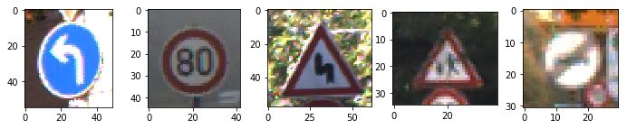

```python
import matplotlib.image as mpimg

new_sign = [34, 5, 21, 28, 41]

test_img = []

for img in new_sign:
    image = mpimg.imread('new_signs/' + str(img) + '.ppm')
    test_img.append(image)

print('Origianl New Test Image')

plt.figure(figsize=(12,2))

for i in range(5):
    plt.subplot(1,5,i+1)
    plt.imshow(test_img[i])
```

### Predict the Sign Type for Each Image

- Run the predictions here and use the model to output the prediction for each image.
- Make sure to pre-process the images with the same pre-processing pipeline used earlier.
- Feel free to use as many code cells as needed.

```
-4.891909588669723
-0.542232331098635
4.291497930743116
5.107566946205111
-5.5439291269017765
```

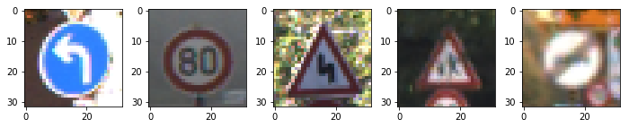

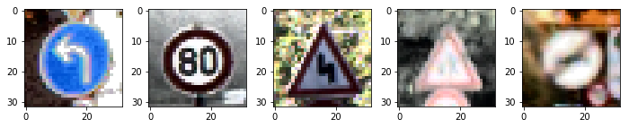

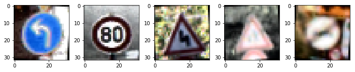

```python
import cv2
import numpy as np
import matplotlib.image as mpimg
import matplotlib.pyplot as plt

preProcessingImage = []

# original images
for i in range(5):
    image = cv2.resize(test_img[i],(32,32))
    preProcessingImage.append(image)

# pre Processing images (equalizeHist)
for i in range(5):
    image = cv2.resize(test_img[i],(32,32))
    img_yuv = cv2.cvtColor(image, cv2.COLOR_BGR2YUV)

    # equalize the histogram of the Y channel
    img_yuv[:,:,0] = cv2.equalizeHist(img_yuv[:,:,0])

    # convert the YUV image back to RGB format
    image = cv2.cvtColor(img_yuv, cv2.COLOR_YUV2BGR)
    preProcessingImage.append(image)

# pre Processing images (equalizeHist + rotation)
for i in range(5):
    image = cv2.resize(test_img[i],(32,32))
    img_yuv = cv2.cvtColor(image, cv2.COLOR_BGR2YUV)

    # equalize the histogram of the Y channel
    img_yuv[:,:,0] = cv2.equalizeHist(img_yuv[:,:,0])

    # convert the YUV image back to RGB format
    image = cv2.cvtColor(img_yuv, cv2.COLOR_YUV2BGR)

    rows,cols = image.shape[:2]
    rot_angle = 10
    rand_ang = np.random.uniform(-rot_angle, rot_angle)
    print(rand_ang)
    rot_mat = cv2.getRotationMatrix2D((cols/2, rows/2), rand_ang, 1.0)

    image = cv2.warpAffine(image , rot_mat, (cols,rows))

    preProcessingImage.append(image)


plt.figure(figsize=(12,2))
for i in range(5):
    plt.subplot(1,5,i+1)
    plt.imshow(preProcessingImage[i])

plt.figure(figsize=(12,2))
for i in range(5):
    plt.subplot(1,5,i+1)
    plt.imshow(preProcessingImage[i+5])

plt.figure(figsize=(12,2))
for i in range(5):
    plt.subplot(1,5,i+1)
    plt.imshow(preProcessingImage[i+10])

plt.show()
```

### Analyze Performance

```
Feature Map of conv2 Layer

New image # 1
```

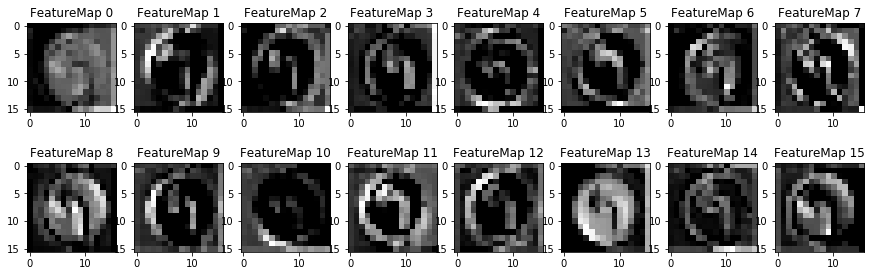

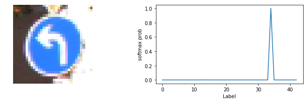

```
Original Label : Turn left ahead -> Detect Label : Turn left ahead ==> It is right
Top 1 Label : Turn left ahead -> acc 99.904%
Top 2 Label : Yield -> acc 0.070%
Top 3 Label : Ahead only -> acc 0.019%
Top 4 Label : Keep right -> acc 0.002%
Top 5 Label : Road work -> acc 0.001%

New image # 2
```

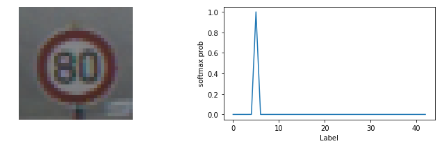

```
Original Label : Speed limit (80km/h) -> Detect Label : Speed limit (80km/h) ==> It is right
Top 1 Label : Speed limit (80km/h) -> acc 99.939%
Top 2 Label : Speed limit (70km/h) -> acc 0.044%
Top 3 Label : Speed limit (50km/h) -> acc 0.011%
Top 4 Label : Speed limit (60km/h) -> acc 0.002%
Top 5 Label : Speed limit (30km/h) -> acc 0.001%

New image # 3
```

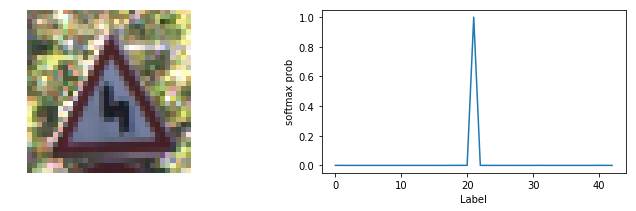

```
Original Label : Double curve -> Detect Label : Double curve ==> It is right
Top 1 Label : Double curve -> acc 99.879%
Top 2 Label : Dangerous curve to the left -> acc 0.034%
Top 3 Label : Roundabout mandatory -> acc 0.031%
Top 4 Label : General caution -> acc 0.016%
Top 5 Label : Wild animals crossing -> acc 0.014%

New image # 4
```

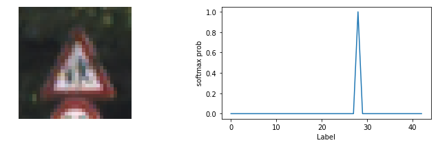

```
Original Label : Children crossing -> Detect Label : Children crossing ==> It is right
Top 1 Label : Children crossing -> acc 99.999%
Top 2 Label : Bumpy road -> acc 0.000%
Top 3 Label : Beware of ice/snow -> acc 0.000%
Top 4 Label : Bicycles crossing -> acc 0.000%
Top 5 Label : Dangerous curve to the right -> acc 0.000%

New image # 5
```

[figure not shown]

```
Original Label : End of no passing -> Detect Label : End of all speed and passing limits ==> It is wrong
Top 1 Label : End of all speed and passing limits -> acc 62.511%
Top 2 Label : End of no passing -> acc 37.034%
Top 3 Label : Dangerous curve to the right -> acc 0.071%
Top 4 Label : End of speed limit (80km/h) -> acc 0.066%
Top 5 Label : End of no passing by vehicles over 3.5 metric tons -> acc 0.044%

New image # 6
```

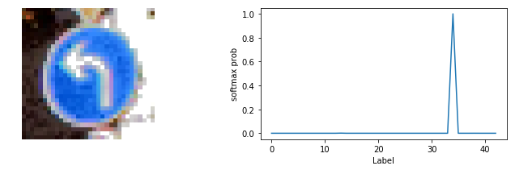

```
Original Label : Turn left ahead -> Detect Label : Turn left ahead ==> It is right
Top 1 Label : Turn left ahead -> acc 99.872%
Top 2 Label : Yield -> acc 0.102%
Top 3 Label : Keep right -> acc 0.017%
Top 4 Label : Ahead only -> acc 0.004%
Top 5 Label : No entry -> acc 0.003%

New image # 7
```

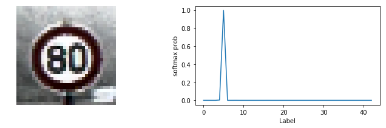

```
Original Label : Speed limit (80km/h) -> Detect Label : Speed limit (80km/h) ==> It is right
Top 1 Label : Speed limit (80km/h) -> acc 99.575%
Top 2 Label : Speed limit (70km/h) -> acc 0.341%
Top 3 Label : Speed limit (120km/h) -> acc 0.026%
Top 4 Label : Speed limit (30km/h) -> acc 0.013%
Top 5 Label : Vehicles over 3.5 metric tons prohibited -> acc 0.008%

New image # 8
```

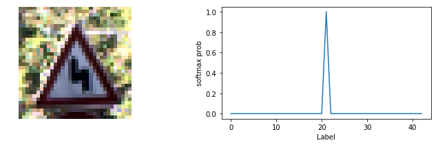

```
Original Label : Double curve -> Detect Label : Double curve ==> It is right
Top 1 Label : Double curve -> acc 99.937%
Top 2 Label : Dangerous curve to the left -> acc 0.026%
Top 3 Label : Roundabout mandatory -> acc 0.013%
Top 4 Label : Slippery road -> acc 0.006%
Top 5 Label : Wild animals crossing -> acc 0.005%

New image # 9
```

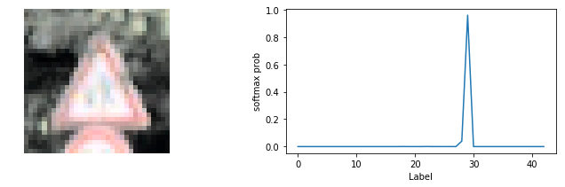

```
Original Label : Children crossing -> Detect Label : Bicycles crossing ==> It is wrong
Top 1 Label : Bicycles crossing -> acc 95.848%
Top 2 Label : Children crossing -> acc 4.013%
Top 3 Label : Bumpy road -> acc 0.046%
Top 4 Label : General caution -> acc 0.037%
Top 5 Label : Slippery road -> acc 0.012%

New image # 10
```

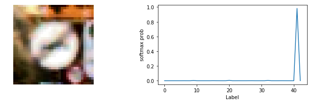

```
Original Label : End of no passing -> Detect Label : End of no passing ==> It is right
Top 1 Label : End of no passing -> acc 98.247%
Top 2 Label : Dangerous curve to the right -> acc 0.547%
Top 3 Label : End of all speed and passing limits -> acc 0.475%
Top 4 Label : No passing -> acc 0.339%
Top 5 Label : End of no passing by vehicles over 3.5 metric tons -> acc 0.075%

New image # 11
```

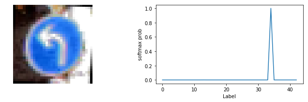

```
Original Label : Turn left ahead -> Detect Label : Turn left ahead ==> It is right
Top 1 Label : Turn left ahead -> acc 99.973%
Top 2 Label : Yield -> acc 0.020%
Top 3 Label : Ahead only -> acc 0.004%
Top 4 Label : Keep right -> acc 0.002%
Top 5 Label : No entry -> acc 0.001%

New image # 12
```

[4 more figures not shown]

```
Original Label : End of no passing -> Detect Label : End of no passing ==> It is right
Top 1 Label : End of no passing -> acc 39.889%
Top 2 Label : End of all speed and passing limits -> acc 33.915%
Top 3 Label : Vehicles over 3.5 metric tons prohibited -> acc 9.926%
Top 4 Label : No passing -> acc 4.094%
Top 5 Label : No vehicles -> acc 3.613%

Accuracy of making 15 Images from the New Sign 5 images : 86.667%
```

```python
import csv

corect_mode = ['It is wrong', 'It is right']

softmax = tf.nn.softmax(logits)


with tf.Session() as sess:
    loader = tf.train.import_meta_graph('lenet_tsr.ckpt.meta')
    loader.restore(sess, tf.train.latest_checkpoint('./'))

    k = 5
    with open('signnames.csv', mode='r') as infile:
        reader = csv.reader(infile)
        s_name = dict((rows[0],rows[1]) for rows in reader)

    my_prediction = sess.run(softmax, feed_dict={x:preProcessingImage, is_training:False, reuse:True})
    print()
    print("Feature Map of conv2 Layer")
    outputFeatureMap(preProcessingImage, conv2)
    #plt.savefig('featureMap_conv2.png')

    top_k = tf.nn.top_k(softmax, k)
    values, indices = sess.run(top_k, feed_dict={x:preProcessingImage, is_training:False, reuse:True})

    class_n = []
    for x in range(43):
        class_n.append(x)

    new_sign_acc = 0.0
    new_sign_crt = 0

    for i in range(15):
        print()
        plt.figure(figsize=(12, 3))
        print("New image #",i+1)
        plt.subplot(1,2,1)
        plt.imshow(preProcessingImage[i])
        plt.axis('off')
        plt.subplot(1,2,2)
        plt.plot(class_n, my_prediction[i])
        plt.xlabel('Label')
        plt.ylabel('softmax prob')
        plt.show()

        if (indices[i,0] == new_sign[i%5]) :
            new_sign_acc = new_sign_acc +1
            new_sign_crt = 1
        else:
            new_sign_crt = 0

        print("Original Label : {} -> Detect Label : {} ==> {}".format(s_name[str(new_sign[i%5])], s_name[str(indices[i,0])], corect_mode[new_sign_crt]))

        for j in range(k):
            print("Top {} Label : {} -> acc {:.3f}%".format(str(j+1), s_name[str(indices[i,j])], values[i,j] * 100,))

    new_sign_acc = new_sign_acc/15

    print()
    print("Accuracy of making 15 Images from the New Sign 5 images : {:.3f}%".format(new_sign_acc * 100,))
```

## Step 4: Visualize the Neural Network's State with Test Images

This Section is not required to complete but acts as an additional excersise for understaning the output of a neural network's weights. While neural networks can be a great learning device they are often referred to as a black box. We can understand what the weights of a neural network look like better by plotting their feature maps. After successfully training your neural network you can see what it's feature maps look like by plotting the output of the network's weight layers in response to a test stimuli image. From these plotted feature maps, it's possible to see what characteristics of an image the network finds interesting. For a sign, maybe the inner network feature maps react with high activation to the sign's boundary outline or to the contrast in the sign's painted symbol.

Provided for you below is the function code that allows you to get the visualization output of any tensorflow weight layer you want. The inputs to the function should be a stimuli image, one used during training or a new one you provided, and then the tensorflow variable name that represents the layer's state during the training process, for instance if you wanted to see what the LeNet lab's feature maps looked like for it's second convolutional layer you could enter conv2 as the tf_activation variable.

For an example of what feature map outputs look like, check out NVIDIA's results in their paper [End-to-End Deep Learning for Self-Driving Cars](https://devblogs.nvidia.com/parallelforall/deep-learning-self-driving-cars/) in the section Visualization of internal CNN State. NVIDIA was able to show that their network's inner weights had high activations to road boundary lines by comparing feature maps from an image with a clear path to one without. Try experimenting with a similar test to show that your trained network's weights are looking for interesting features, whether it's looking at differences in feature maps from images with or without a sign, or even what feature maps look like in a trained network vs a completely untrained one on the same sign image.

[figure not shown]

Your output should look something like this (above)

### Question 9

Discuss how you used the visual output of your trained network's feature maps to show that it had learned to look for interesting characteristics in traffic sign images

**Answer:**

- It is shown results of feature-map of conv layer as follows:
- It seems to be compose of low-pass-filter, high-pass-filter, gradient filter, etc of weights of convolution layers

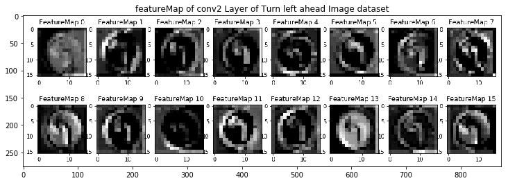

```python
import cv2
import numpy as np
import matplotlib.image as mpimg
import matplotlib.pyplot as plt

image = mpimg.imread('featureMap_conv2_result.png')
plt.figure(figsize=(24,4))
plt.imshow(image)
plt.title('featureMap of conv2 Layer of Turn left ahead Image dataset')
plt.show()
```

### Project Writeup

Once you have completed the code implementation, document your results in a project writeup using this [template](https://github.com/udacity/CarND-Traffic-Sign-Classifier-Project/blob/master/writeup_template.md) as a guide. The writeup can be in a markdown or pdf file.